# Pacote edu

Eduardo Peixoto

27/02/2021

## Pacote do Edu

Essa é uma iniciativa independente sem fins lucrativos de código aberto para facilitar o uso e aprendizado do R. As funções foram criadas para facilitar operações simples e comuns do uso. Ainda está em fase de desenvolvimento e contribuições e sugestões são muito bem-vindas.

> Você já pensou em digitar em português o que quer e aparecer uma tabela/gráfico que você precisa? Esse é o objetivo.

Nos exemplos usei o banco de dados iris, que ja vem no R, precisa importar o seu banco antes e o nome que ele ficar é o que se deve substituir por “iris”. Pode usar as funções importarcsv ou importarexcel descritas abaixo.

##site

- https://github.com/eduardompeixoto/edu/Página.html

## instalação

- devtools::install_git(“https://github.com/eduardompeixoto/edu”)

**Dependências:**

- gtsummary
- dplyr
- epiDisplay
- sjPlot
- stats
- RcmdrMisc
- base
- tcltk
- snippet
- ggplot2
- ggstatsplot
- tidyverse
- rstantools
- htmlTable

## comandos

### importarcsv

selecione o delimitador de texto e em seguida o decimal

```r
#banco <-edu::importarcsv()
```

### importarexcel

```r
#banco<-edu::importarexcel()
```

### tabelarumbancoporumavarquali

```r
iris$a<-0
iris$a[iris$Sepal.Length>5]<-1
iris$a<-as.factor(iris$a)
edu::tabelarumbancoporumavarquali(iris)
```

| **Characteristic** | **0**, N = 32<sup>1</sup> | **1**, N = 118<sup>1</sup> |
| --- | --- | --- |
| Sepal.Length | 4.85 (4.60, 5.00) | 6.10 (5.60, 6.57) |
| Sepal.Width | 3.15 (3.00, 3.40) | 3.00 (2.80, 3.30) |
| Petal.Length | 1.40 (1.37, 1.60) | 4.70 (3.92, 5.38) |
| Petal.Width | 0.20 (0.20, 0.30) | 1.50 (1.20, 1.90) |
| Species |  |  |
| setosa | 28 (87.50%) | 22 (18.64%) |
| versicolor | 3 (9.38%) | 47 (39.83%) |
| virginica | 1 (3.12%) | 49 (41.53%) |

<sup>*1*</sup> Median (IQR); n (%)

### testesdesfechoqualitativo

Esse comando é um dos meus favoritos, ele faz os testes de hipótese considerando normalidade seleciona o teste automaticamente para o analista, tudo que tem a fazer é selecionar o desfecho em uma janela que vai abrir e pronto. Usa 5% de significância.

**O Desfecho precisa ser qualitativo e estar sendo lido como factor no r, precisa ter pelo menos três observações em cada extrado do factor versus cada variável*

#### uso

```r
edu::testesdesfechoqualitativo(iris)
```

|  | setosa | versicolor | virginica | Test stat. | P value |
| --- | --- | --- | --- | --- | --- |
| Total | 50 | 50 | 50 |  |  |
| Sepal.Length : Sepal.Length |  |  |  | Kruskal-Wallis test | < 0.001 |
| median(IQR) | 5 (4.8,5.2) | 5.9 (5.6,6.3) | 6.5 (6.2,6.9) |  |  |
| Sepal.Width : Sepal.Width |  |  |  | ANOVA F-test (2, 147 df) = 49.16 | < 0.001 |
| mean(SD) | 3.4 (0.4) | 2.8 (0.3) | 3 (0.3) |  |  |
| Petal.Length : Petal.Length |  |  |  | Kruskal-Wallis test | < 0.001 |
| median(IQR) | 1.5 (1.4,1.6) | 4.3 (4,4.6) | 5.6 (5.1,5.9) |  |  |
| Petal.Width : Petal.Width |  |  |  | Kruskal-Wallis test | < 0.001 |
| median(IQR) | 0.2 (0.2,0.3) | 1.3 (1.2,1.5) | 2 (1.8,2.3) |  |  |
| desfecho : desfecho |  |  |  | Chisq. (4 df) = 300 | < 0.001 |
| setosa | 50 (100) | 0 (0) | 0 (0) |  |  |
| versicolor | 0 (0) | 50 (100) | 0 (0) |  |  |
| virginica | 0 (0) | 0 (0) | 50 (100) |  |  |
| a : a |  |  |  | Chisq. (2 df) = 53.95 | < 0.001 |
| 0 | 28 (87.5) | 3 (9.4) | 1 (3.1) |  |  |
| 1 | 22 (18.6) | 47 (39.8) | 49 (41.5) |  |  |

```r
###ou
##require(edu)
##testesdesfechoqualitativo(iris)
```

### correlacao

Faz uma tabela bonitinha de matrix de correlação de spearman (não paramétrica), só considera as variáveis quantitativas. Bom para avaliar a associação entre várias variáveis quantitativas de uma vez só.

#### uso

```r
edu::correlacao(iris)
```

|  | Sepal.Length | Sepal.Width | Petal.Length | Petal.Width |
| --- | --- | --- | --- | --- |
| Sepal.Length | 1 | -0.17 | 0.88 | 0.83 |
| Sepal.Width | -0.17 | 1 | -0.31 | -0.29 |
| Petal.Length | 0.88 | -0.31 | 1 | 0.94 |
| Petal.Width | 0.83 | -0.29 | 0.94 | 1 |

### resumosnumericos

Faz uma tabela bonitinha com média, sd (desvio padrão), IQR (intervalo interquartílico , a diferença entre 75% e 25%), o valor mínimo (0%), em ordem crescente até 25% das obsevações (primeiro quartil),em ordem crescente até 50% das obsevações (segundo quartil ou mediana), em ordem crescente até 75% das obsevações (terceiro quartil) e o valor máximo (100%).Só considera as variáveis quanti.

#### uso

```r
edu::resumosnumericos(iris)
```

|  | mean | sd | IQR | 0% | 25% | 50% | 75% | 100% |
| --- | --- | --- | --- | --- | --- | --- | --- | --- |
| Sepal.Length | 5.84 | 0.83 | 1.3 | 4.3 | 5.1 | 5.8 | 6.4 | 7.9 |
| Sepal.Width | 3.06 | 0.44 | 0.5 | 2 | 2.8 | 3 | 3.3 | 4.4 |
| Petal.Length | 3.76 | 1.77 | 3.5 | 1 | 1.6 | 4.35 | 5.1 | 6.9 |
| Petal.Width | 1.2 | 0.76 | 1.5 | 0.1 | 0.3 | 1.3 | 1.8 | 2.5 |

### criarsubbanco

```r
temp<-edu::criarsubbanco(iris)
```

### modelo_logistico

```r
temp<-edu::criarsubbanco(iris)
edu::modelo_logistico(temp)
```

|  | desfecho |  |  |
| --- | --- | --- | --- |
| Predictors | Odds Ratios | CI | p |
| (Intercept) | 0.00 | 0.00 – 0.00 | **<0.001** |
| Sepal.Width | 12784.57 | 164.85 – 12150771.09 | **0.001** |
| Petal.Length | 215.62 | 6.60 – 23392.46 | **0.008** |
| Petal.Width | 1.90 | 0.00 – 2833.21 | 0.852 |
| Species [versicolor] | 1.10 | 0.00 – 10440.00 | 0.984 |
| Species [virginica] | 0.00 | 0.00 – 306.12 | 0.304 |
| Observations | 150 |  |  |
| R<sup>2</sup> Tjur | 0.716 |  |  |

### modelo_gaussiano

```r
temp<-edu::criarsubbanco(iris)
edu::modelo_gaussiano(temp)
```

|  | desfecho |  |  |
| --- | --- | --- | --- |
| Predictors | Estimates | CI | p |
| (Intercept) | 2.17 | 1.62 – 2.72 | **<0.001** |
| Sepal.Width | 0.50 | 0.33 – 0.66 | **<0.001** |
| Petal.Length | 0.83 | 0.69 – 0.96 | **<0.001** |
| Petal.Width | -0.32 | -0.61 – -0.02 | **0.039** |
| Species [versicolor] | -0.72 | -1.19 – -0.25 | **0.003** |
| Species [virginica] | -1.02 | -1.68 – -0.37 | **0.003** |
| Observations | 150 |  |  |
| R<sup>2</sup> Nagelkerke | 0.903 |  |  |

### resumonumericooucategorico

```r
edu::resumonumericooucategorico(iris)
```

| **Characteristic** | **N = 150**<sup>1</sup> |
| --- | --- |
| Sepal.Length | 5.80 (5.10, 6.40) |
| Sepal.Width | 3.00 (2.80, 3.30) |
| Petal.Length | 4.35 (1.60, 5.10) |
| Petal.Width | 1.30 (0.30, 1.80) |
| Species |  |
| setosa | 50 (33.33%) |
| versicolor | 50 (33.33%) |
| virginica | 50 (33.33%) |
| a |  |
| 0 | 32 (21.33%) |
| 1 | 118 (78.67%) |

<sup>*1*</sup> Median (IQR); n (%)

### boxplotpareado

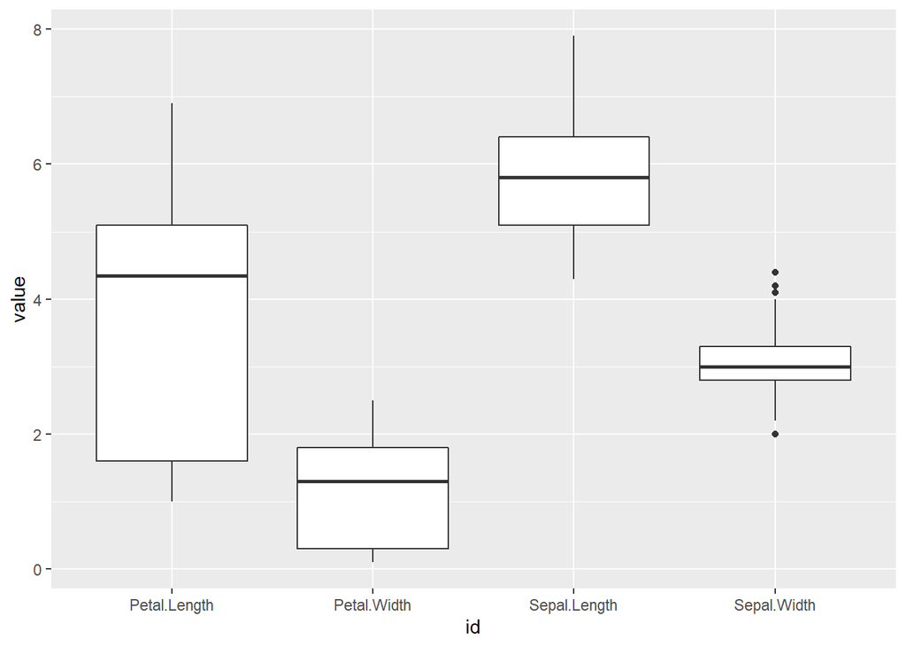

```r
edu::boxplotpareado(iris)
```

### boxplotbolado

[output not shown]

[output not shown]

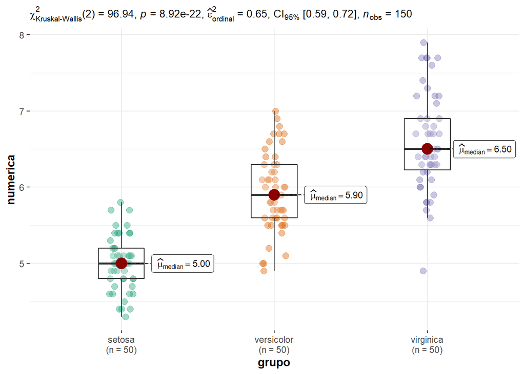

```r
edu::boxplotbolado(iris)
```